# Clinical Digital Twin — Full Simulation Report

## Executive summary

**Run:** `sim1_baseline` · branch **`B`** · 30 day(s) · 10 residents · generated 2026-07-17 15:47:40.052729.

This is a fully auditable account of one branch of the multi-agent simulation over the fixed 10-resident module. All data is **synthetic**.

| Metric | Value |
| --- | --- |
| Days completed | 30 |
| Model predictions written | 300 |
| Checkpoints passed | 120 |
| Checkpoints warned | 0 |
| Checkpoints failed | 0 |
| Degraded agent decisions (invalid → prior reused) | 0 |
| Highest 7-day risk resident | `P06` |

## Per-resident risk trajectories

Each panel plots the model’s reported fall probability over the run: 24-hour (blue) and 7-day (orange). Dates run left→right; probability on the y-axis.

### P01 ([SYNTHETIC] Rosario)

Final tiers: 24h **Low**, 7d **Low** · peak 7d risk 68.2%.

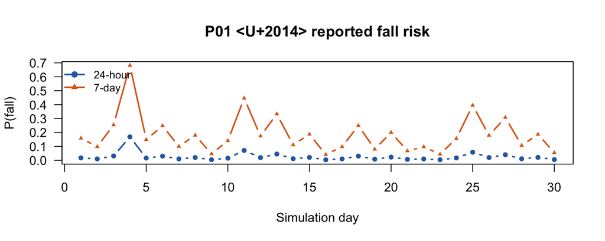

### P02 ([SYNTHETIC] Antonio)

Final tiers: 24h **Low**, 7d **High** · peak 7d risk 86.1%.

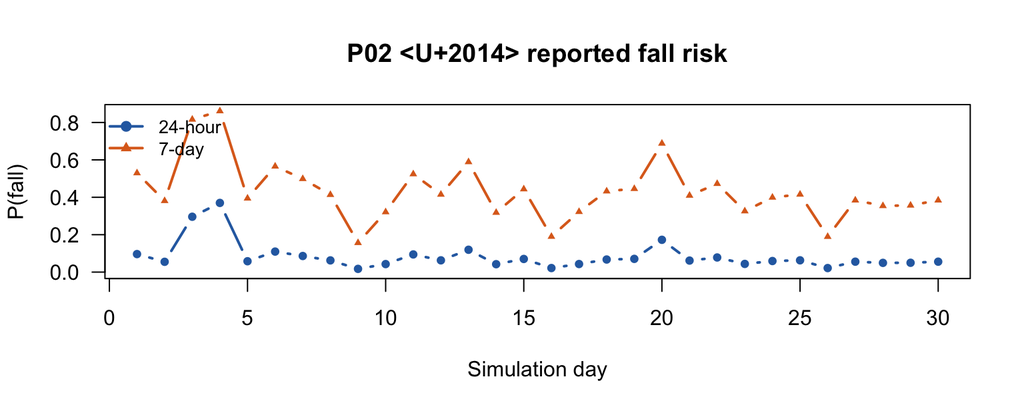

### P03 ([SYNTHETIC] Carmen)

Final tiers: 24h **Low**, 7d **Low** · peak 7d risk 35.1%.

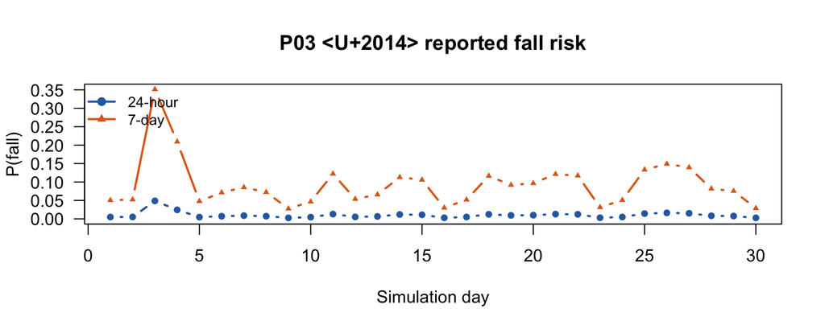

### P04 ([SYNTHETIC] Manuel)

Final tiers: 24h **Low**, 7d **Low** · peak 7d risk 10.1%.

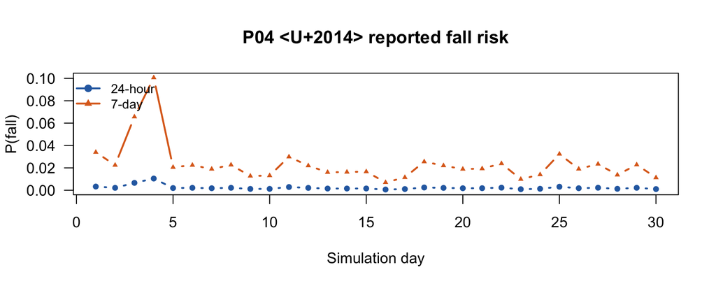

### P05 ([SYNTHETIC] Dolores)

Final tiers: 24h **Low**, 7d **Low** · peak 7d risk 55.4%.

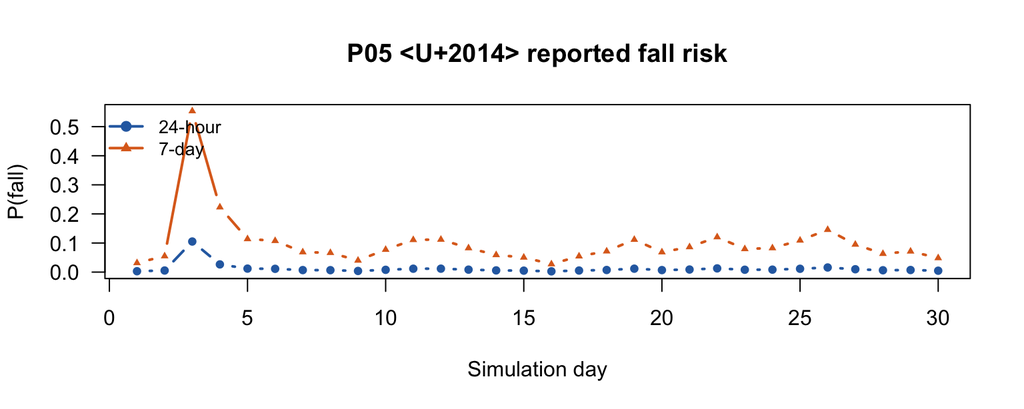

### P06 ([SYNTHETIC] Francisco)

Final tiers: 24h **Low**, 7d **High** · peak 7d risk 97.0%.

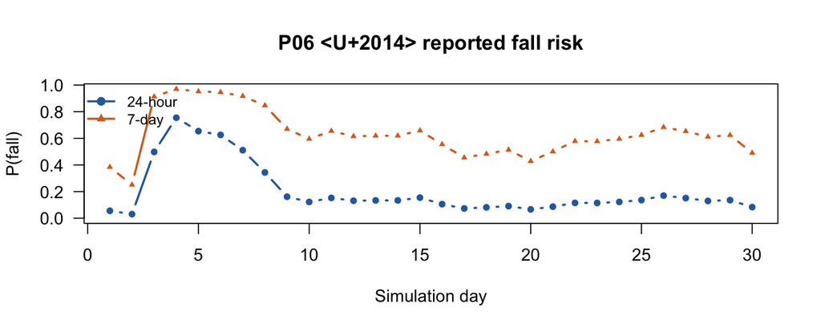

### P07 ([SYNTHETIC] Isabel)

Final tiers: 24h **Low**, 7d **Moderate** · peak 7d risk 83.4%.

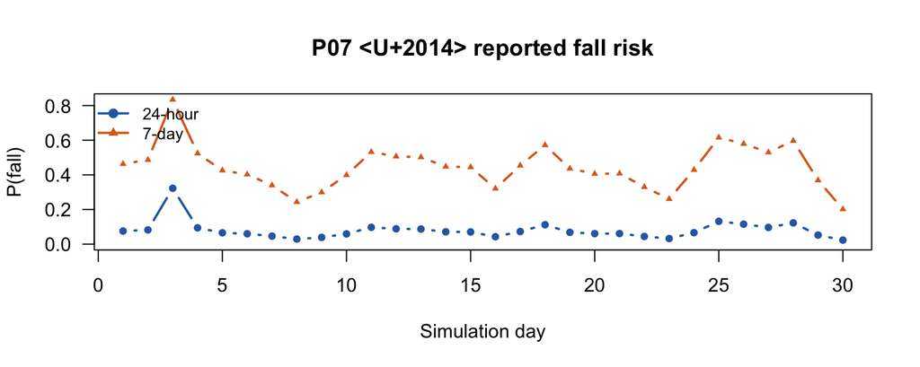

### P08 ([SYNTHETIC] Joaquin)

Final tiers: 24h **Low**, 7d **Low** · peak 7d risk 36.0%.

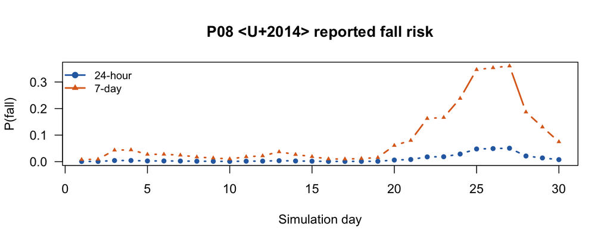

### P09 ([SYNTHETIC] Pilar)

Final tiers: 24h **Low**, 7d **Moderate** · peak 7d risk 67.1%.

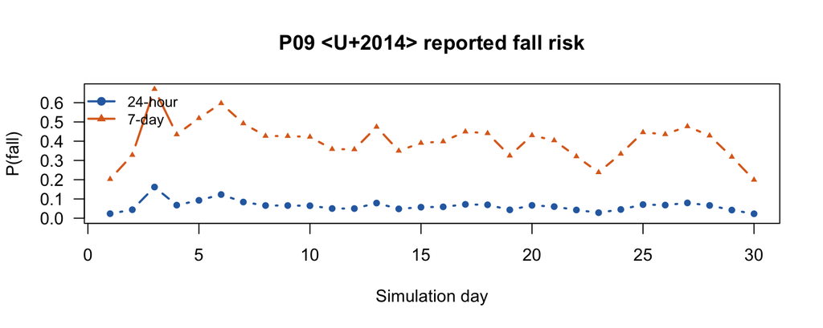

### P10 ([SYNTHETIC] Vicente)

Final tiers: 24h **Low**, 7d **Low** · peak 7d risk 21.8%.

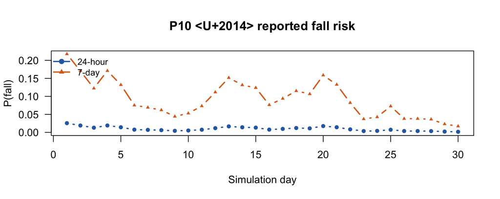

## Checkpoint gate log

Every daily checkpoint step and its status. `pass`/`warn` proceed; `fail` halts the run.

| Day | Step | Status | Detail |
| --- | --- | --- | --- |
| 1 | social | pass | NA |
| 1 | agent_json | pass | NA |
| 1 | biological | pass | NA |
| 1 | model | pass | NA |
| 2 | social | pass | NA |
| 2 | agent_json | pass | NA |
| 2 | biological | pass | NA |
| 2 | model | pass | NA |
| 3 | social | pass | NA |
| 3 | agent_json | pass | NA |
| 3 | biological | pass | NA |
| 3 | model | pass | NA |
| 4 | social | pass | NA |
| 4 | agent_json | pass | NA |
| 4 | biological | pass | NA |
| 4 | model | pass | NA |
| 5 | social | pass | NA |
| 5 | agent_json | pass | NA |
| 5 | biological | pass | NA |
| 5 | model | pass | NA |
| 6 | social | pass | NA |
| 6 | agent_json | pass | NA |
| 6 | biological | pass | NA |
| 6 | model | pass | NA |
| 7 | social | pass | NA |
| 7 | agent_json | pass | NA |
| 7 | biological | pass | NA |
| 7 | model | pass | NA |
| 8 | social | pass | NA |
| 8 | agent_json | pass | NA |

[output cut: 90 more lines]

## Traceability appendix

Per-day counts of agent decisions and model predictions, plus how many decisions were degraded (invalid agent output → prior-day decision reused). This is the audit trail linking each simulated day to its persisted rows.

| Day | Decisions | Invalid (reused) | Predictions |
| --- | --- | --- | --- |
| 1 | 10 | 0 | 10 |
| 2 | 10 | 0 | 10 |
| 3 | 10 | 0 | 10 |
| 4 | 10 | 0 | 10 |
| 5 | 10 | 0 | 10 |
| 6 | 10 | 0 | 10 |
| 7 | 10 | 0 | 10 |
| 8 | 10 | 0 | 10 |
| 9 | 10 | 0 | 10 |
| 10 | 10 | 0 | 10 |
| 11 | 10 | 0 | 10 |
| 12 | 10 | 0 | 10 |
| 13 | 10 | 0 | 10 |
| 14 | 10 | 0 | 10 |
| 15 | 10 | 0 | 10 |
| 16 | 10 | 0 | 10 |
| 17 | 10 | 0 | 10 |
| 18 | 10 | 0 | 10 |
| 19 | 10 | 0 | 10 |
| 20 | 10 | 0 | 10 |
| 21 | 10 | 0 | 10 |
| 22 | 10 | 0 | 10 |
| 23 | 10 | 0 | 10 |
| 24 | 10 | 0 | 10 |
| 25 | 10 | 0 | 10 |
| 26 | 10 | 0 | 10 |
| 27 | 10 | 0 | 10 |
| 28 | 10 | 0 | 10 |
| 29 | 10 | 0 | 10 |
| 30 | 10 | 0 | 10 |

## Validation — virtual case-use evidence

This run is presented as a *virtual case use* of the system. Four validation axes accompany it: (i) technical integrity, (ii) experimental validity, (iii) clinical face-validity, and (iv) safety / leakage.

### (i) Technical integrity

Automated daily gates over biological plausibility and model-output sanity.

| Gate family | Outcomes | All predictions in [0,1] |
| --- | --- | --- |
| Biological plausibility | pass 30 / warn 0 / fail 0 | — |
| Model-output sanity | pass 30 / warn 0 / fail 0 | TRUE |
| **All checkpoints** | pass 120 / warn 0 / fail 0 | — |

### (ii) Experimental validity (observable side)

The blind P08 experiment’s hidden A/B fall outcome is a **separate privileged analysis** and is deliberately absent here. What the report *can* show is P08’s observable model risk and, on the intervention branch, whether the scripted preventive intervention was logged.

```
## Branch **B**. Intervention fired: **TRUE** (2 logged preventive review(s)).
```

```
## P08 peak 7-day model risk: **36.0%**.
```

```
## _A/B fall-outcome comparison is a separate privileged analysis; this report shows only observable model risk._
```

### (iii) Clinical face-validity

Each resident’s designed risk signature (from their ficha) paired with the observed model outcome, for eyeball validation that trajectories behave as intended.

| Resident | Expected signature | Observed final 7d tier | Observed peak 7d |
| --- | --- | --- | --- |
| P01 | fear-of-falling: activity below physical capacity, worse without physio | Low | 68.2% |
| P02 | Parkinson’s wearing-off: mobility fluctuates around med timing | High | 86.1% |
| P03 | night-concentrated risk; daytime activity non-predictive | Low | 35.1% |
| P04 | stable low-risk control (social connector) | Low | 10.1% |
| P05 | afternoon knee pain: PM mobility below AM | Low | 55.4% |
| P06 | progressive decline over 5-7 days after new diuretic | High | 97.0% |
| P07 | morning instability/drowsiness (night benzodiazepine) | Moderate | 83.4% |
| P08 | subtle risk not obvious from step volume (blind experiment) | Low | 36.0% |
| P09 | high stable baseline; occasional night agitation | Moderate | 67.1% |
| P10 | non-linear post-hospital recovery (upward trend) | Low | 21.8% |

### (iv) Safety / leakage attestation

The report payload and the P08 clinical surface are scanned for any restricted field (`latent`, `hazard`, `fall_sampled`, `intervention_fired`). The hidden ground-truth table has no exported getter by design.

```
## - Restricted pattern scanned: `latent|hazard|fall_sampled|intervention_fired`
```

```
## - Leaked fields found in report payload: **0**
```

```
## - Ground-truth getter exported: **FALSE**
```

```
## - P08 clinical surface clean: **TRUE**
```

```
##
## **Attestation: PASS** — no hidden P08 experiment state leaked onto any clinical surface.
```

*Synthetic data only. Not for clinical use.*